# Solving the Problem

### Here i present my solution to this particular problem presented to me this afternoon

# Lets check the importance of the variables

```python
df_to_explore.info()
```

```
<class 'pandas.core.frame.DataFrame'>
RangeIndex: 9134 entries, 0 to 9133
Data columns (total 24 columns):
 #   Column                         Non-Null Count  Dtype
---  ------                         --------------  -----
 0   Customer                       9134 non-null   object
 1   State                          9134 non-null   object
 2   Customer Lifetime Value        9134 non-null   float64
 3   Response                       9134 non-null   object
 4   Coverage                       9134 non-null   object
 5   Education                      9134 non-null   object
 6   Effective To Date              9134 non-null   datetime64[ns]
 7   EmploymentStatus               9134 non-null   object
 8   Gender                         9134 non-null   object
 9   Income                         9134 non-null   float64
```

[output cut: 16 more lines]

# What about correlations?

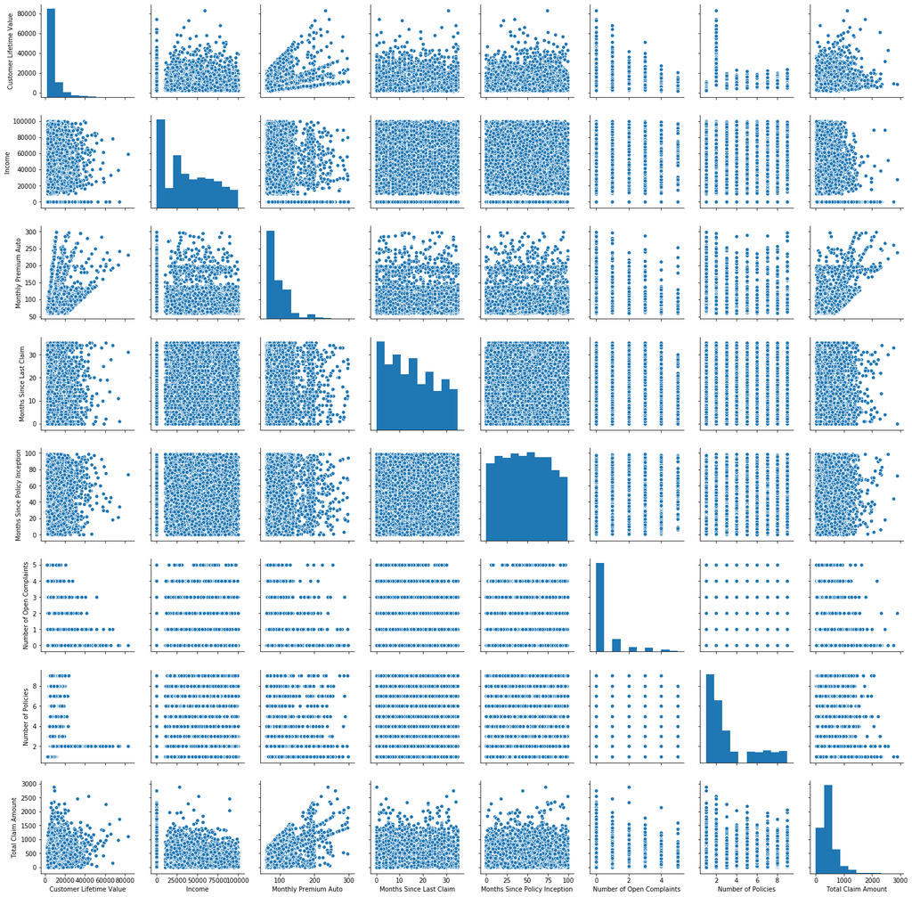

```python
sns.pairplot(data=df_to_explore)
```

# And maybe segmenting by Sales channel

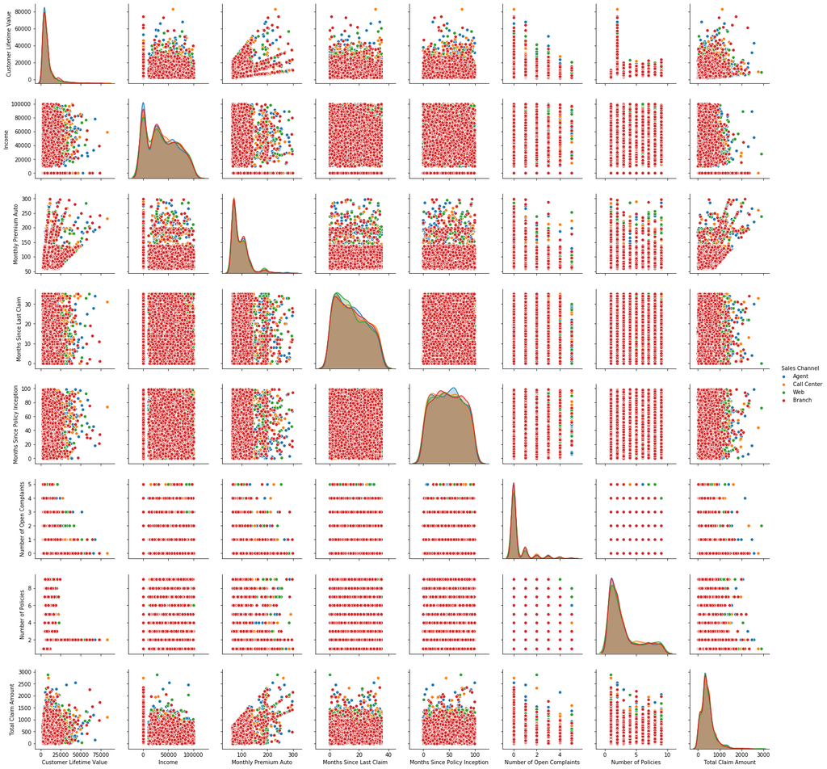

```python
sns.pairplot(data=df_to_explore,hue="Sales Channel")
```

# Gender?

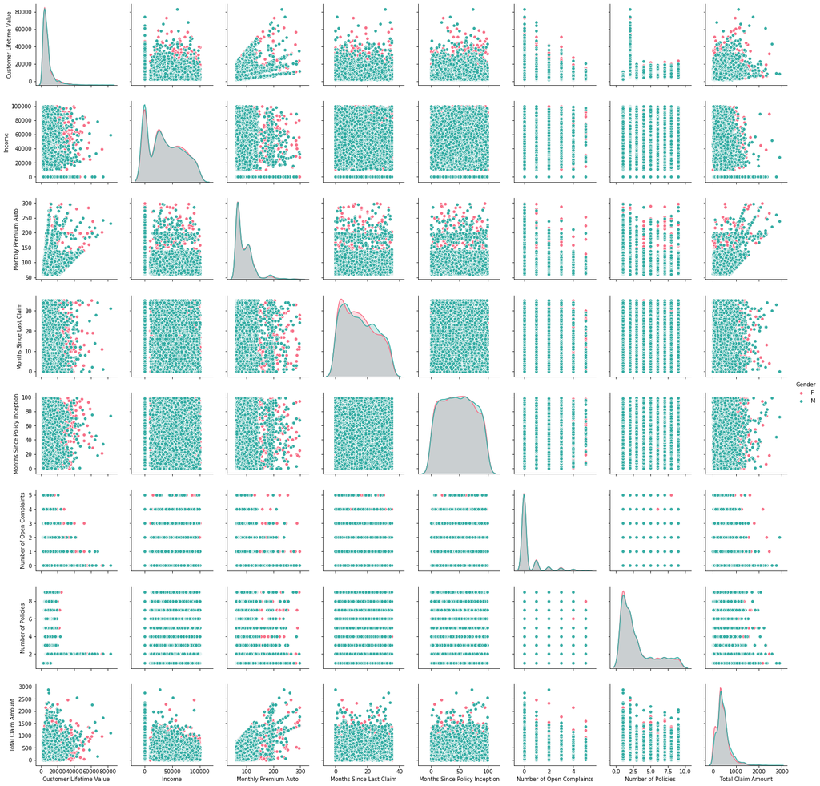

```python
sns.pairplot(data=df_to_explore,hue="Gender",palette="husl")
```

# Segmenting by state and sales channel

```python
df_to_explore.groupby(["Sales Channel","State","Response"]).agg(Total=("Gender","count"))
```

| Sales Channel | State | Response | Total |
| --- | --- | --- | --- |
| Agent | Arizona | No | 518 |
|  |  | Yes | 125 |
|  | California | No | 981 |
|  |  | Yes | 220 |
|  | Nevada | No | 267 |
|  |  | Yes | 63 |
|  | Oregon | No | 787 |
|  |  | Yes | 201 |
|  | Washington | No | 258 |
|  |  | Yes | 57 |
| Branch | Arizona | No | 422 |
|  |  | Yes | 47 |
|  | California | No | 788 |
|  |  | Yes | 112 |
|  | Nevada | No | 219 |
|  |  | Yes | 28 |
|  | Oregon | No | 639 |
|  |  | Yes | 80 |
|  | Washington | No | 205 |
|  |  | Yes | 27 |
| Call Center | Arizona | No | 313 |
|  |  | Yes | 40 |
|  | California | No | 530 |
|  |  | Yes | 75 |
|  | Nevada | No | 148 |
|  |  | Yes | 15 |
|  | Oregon | No | 447 |
|  |  | Yes | 50 |
|  | Washington | No | 135 |
|  |  | Yes | 12 |
| Web | Arizona | No | 207 |
|  |  | Yes | 31 |
|  | California | No | 395 |
|  |  | Yes | 49 |
|  | Nevada | No | 124 |
|  |  | Yes | 18 |
|  | Oregon | No | 352 |
|  |  | Yes | 45 |
|  | Washington | No | 91 |
|  |  | Yes | 13 |

# It is hard to see, let's plot it

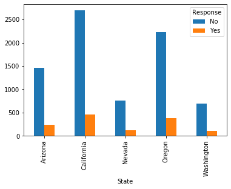

```python
df_to_explore.groupby(["State","Response"]).agg(Total=("Gender","count")).unstack(1)["Total"].plot(kind="bar")
plt.show()
```

# We could also check the percentage of engagement segmenting by the offer

```python
df_tmp=df_to_explore.groupby((["Renew Offer Type","Response"])).agg(Percentage=("Gender","count"))
df_tmp.groupby(level=0).apply(lambda x: 100*x / float(x.sum()))
```

| Renew Offer Type | Response | Percentage |
| --- | --- | --- |
| Offer1 | No | 84.168443 |
|  | Yes | 15.831557 |
| Offer2 | No | 76.623377 |
|  | Yes | 23.376623 |
| Offer3 | No | 97.905028 |
|  | Yes | 2.094972 |
| Offer4 | No | 100.000000 |

# having more granularity we can check the type of car of the User

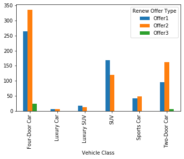

```python
df_to_explore[df_to_explore["Response"]=="Yes"].groupby((["Vehicle Class","Renew Offer Type"])).agg(Total=("Gender","count"))["Total"].unstack().plot(kind="bar")
```

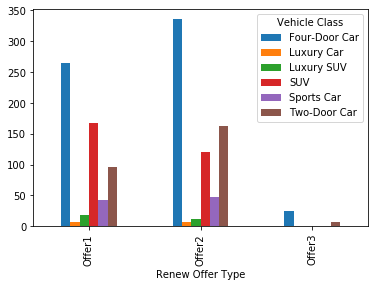

```python
df_to_explore[df_to_explore["Response"]=="Yes"].groupby((["Renew Offer Type", "Vehicle Class"])).agg(Total=("Gender","count"))["Total"].unstack().plot(kind="bar")
```

## We therefore conclude that the offer that performed the best was the 2 offer and the worts being the 4

# Getting back to the Sales channel Performance

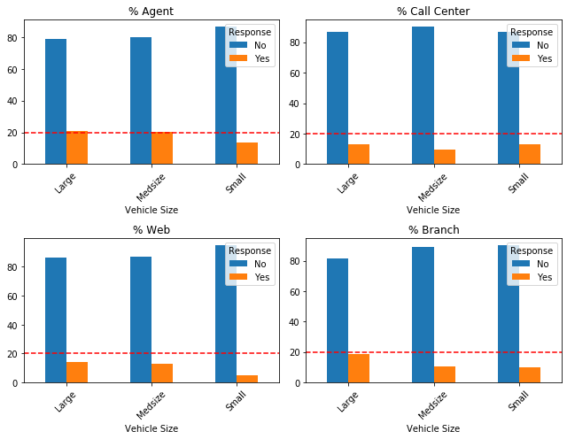

```python
plt.figure(figsize=(9,7))
k=1
for i in df_to_explore["Sales Channel"].unique():
    ax=plt.subplot(2,2,k)
    df_tmp=df_to_explore[df_to_explore["Sales Channel"]==i].groupby(["Vehicle Size","Response"]).agg(Total=("Gender","count"))
    df_tmp.groupby(level=0).apply(lambda x: 100*x / float(x.sum()))["Total"].unstack().plot(kind="bar",ax=ax, rot = 45, title ="% "+i)
    plt.axhline(y=20,color="red",linestyle="--")
    k+=1
plt.tight_layout()
plt.show()
```

# And What about a segmentation of our customers by their CLV and time since they started with our products?

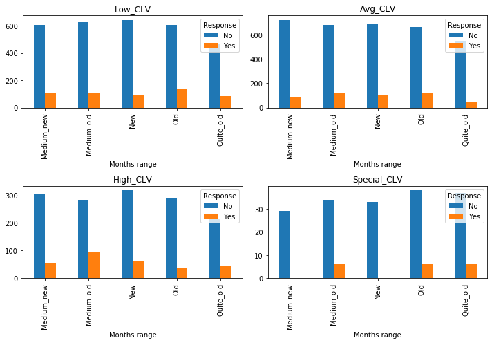

```python
plt.figure(figsize=(10,7))
k=1
for i in df_to_explore["CLV Range"].unique():
    ax=plt.subplot(2,2,k)
    df_to_explore[df_to_explore["CLV Range"]==i].groupby(["Months range","Response"]).agg(Total=("Gender","count"))["Total"].unstack().plot(kind="bar",ax=ax,title=i)
    k+=1
plt.tight_layout()
plt.show()
```

### For this case we see that people cataloged as "High_CLV" are the ones how performed the best. Something interesting to notice is that for the case of "Special CLV" there is a tendency from the new users as well as the Medium Users to Response "No" being this a sign of alarm to for the enterprise to take actions.